# Robust design-survival only

Michael E. Colvin

1 September 2016

Some preliminaries.

```r
library(R2jags)
```

For this idealized (it is very much a best case scenario) there are 5 primary sampling occasions and 7 secondary occasions. Additionally we are going to fix survival (phi; $\phi$) and capture probability ($p$) to 0.8 and 0.4 respectively. Lets assign those for the simulation.

```r
nprim=5
nsec<-7
phi=0.8
p<-0.4
```

One thing the keep in mind is that $\phi$ and $p$ are assumed to be constant. Therefore $\phi$ does not vary among primary sampling occasions and $p$ does not vary among secondary occasions. This is a simplifying assumption for this example.

In order to estimate population abundance from recaptures of individuals we need to set up a super population. This is a vector of 0s and 1s that assign whether an individual is included in the population. Suppose we have a population of 100 individuals. This can be represented as a vector of 100 1s and some zeros. Adding the zeros is the ‘data augmentation’ trick needed to estimate abundance. In the super population there are 200 ‘spots’ an individual can occupy. Because there are 100 individuals the ‘occupancy’ rate is 0.5. This is one of the values estimated by the model below we will define it as $\omega$.

```r
Z<- c(rep(1,100), rep(0,100))
Z
```

```
##   [1] 1 1 1 1 1 1 1 1 1 1 1 1 1 1 1 1 1 1 1 1 1 1 1 1 1 1 1 1 1 1 1 1 1 1 1
##  [36] 1 1 1 1 1 1 1 1 1 1 1 1 1 1 1 1 1 1 1 1 1 1 1 1 1 1 1 1 1 1 1 1 1 1 1
##  [71] 1 1 1 1 1 1 1 1 1 1 1 1 1 1 1 1 1 1 1 1 1 1 1 1 1 1 1 1 1 1 0 0 0 0 0
## [106] 0 0 0 0 0 0 0 0 0 0 0 0 0 0 0 0 0 0 0 0 0 0 0 0 0 0 0 0 0 0 0 0 0 0 0
## [141] 0 0 0 0 0 0 0 0 0 0 0 0 0 0 0 0 0 0 0 0 0 0 0 0 0 0 0 0 0 0 0 0 0 0 0
## [176] 0 0 0 0 0 0 0 0 0 0 0 0 0 0 0 0 0 0 0 0 0 0 0 0 0
```

We can calculate the super population size by summing Z and $\omega$ as the mean of Z.

```r
super_N_true<- sum(Z)
omega_true<- mean(Z)
super_N_true
```

```
## [1] 100
```

```r
omega_true
```

```
## [1] 0.5
```

Now that the super population is defined the time dynamics can play out. For this example the super population is the initial population. This example does not include any immigration emigration or recruitment. I find with this stuff it is best to start basic and add complexity.

I terms of the survival process, it is modelled as the probability of a 1 becoming a 0 between T and T+1. This process for individuals can be contained in a matrix that is 200 row long and 5 columns wide. The survival process is *conditional* on being included in the super population. Therefore you will see the bottom half of this 200x5 matrix will be all 0s.

To simulate this we first need to set up a 200x5 matrix to hold our 1s and 0s.

```r
ZZ<- matrix(NA,200,5)
```

Recall that for this example the super population is the initial population size. So we define the first column of ZZ as Z.

```r
ZZ[,1]<- Z
ZZ
```

```
##        [,1] [,2] [,3] [,4] [,5]
##   [1,]    1   NA   NA   NA   NA
##   [2,]    1   NA   NA   NA   NA
##   [3,]    1   NA   NA   NA   NA
##   [4,]    1   NA   NA   NA   NA
##   [5,]    1   NA   NA   NA   NA
##   [6,]    1   NA   NA   NA   NA
##   [7,]    1   NA   NA   NA   NA
##   [8,]    1   NA   NA   NA   NA
##   [9,]    1   NA   NA   NA   NA
##  [10,]    1   NA   NA   NA   NA
##  [11,]    1   NA   NA   NA   NA
##  [12,]    1   NA   NA   NA   NA
##  [13,]    1   NA   NA   NA   NA
##  [14,]    1   NA   NA   NA   NA
```

[output cut: 186 more lines]

Now that we have the status of our individuals at T=1 defined. In ZZ fish assigned a 1 are alive and fish are assigned a 0. The 0 assignment is a bit tricky because it can arise from either being dead or not included in the super population. But if you know Z, your super population and ZZ you can figure this out. For example, if a fish is included in the super population (Z=1) but is assigned a 0 at some point in ZZ it is a death. Alternatively if a fish is not in the super population (Z=0) then it can never have a 1 in ZZ. This is the idea of ‘conditional’ survival. A fish can only survive if it is in the super population and alive in the previous primary occasion (i.e., Z=1 and ZZ[t-1] =1). Hence the multiplication of $\phi$ by ZZ to account for whether a fish was previously alive and Z that the fish is included in the super population. If a fish was not previously alive or in the super population the probability of surviving is $\phi \cdot 0 \cdot 0$. This keeps zombie fish from rising from the dead and curtails spontaneous generation.

So we can simply play these dynamics out using the code below.

```r
for(i in 2:5)
    {
    ZZ[,i]<- rbinom(200,1,phi*ZZ[,i-1]*Z)
    }
ZZ
```

```
##        [,1] [,2] [,3] [,4] [,5]
##   [1,]    1    1    0    0    0
##   [2,]    1    1    1    1    0
##   [3,]    1    1    1    1    1
##   [4,]    1    0    0    0    0
##   [5,]    1    1    1    1    0
##   [6,]    1    0    0    0    0
##   [7,]    1    1    0    0    0
##   [8,]    1    0    0    0    0
##   [9,]    1    1    1    1    1
##  [10,]    1    0    0    0    0
##  [11,]    1    1    0    0    0
##  [12,]    1    1    1    1    1
##  [13,]    1    1    1    1    1
##  [14,]    1    1    0    0    0
```

[output cut: 186 more lines]

Now ZZ contains the information that accounts for super population inclusion and the survival process. We have effectively modeled the demographic process! Lets look at what is playing out.

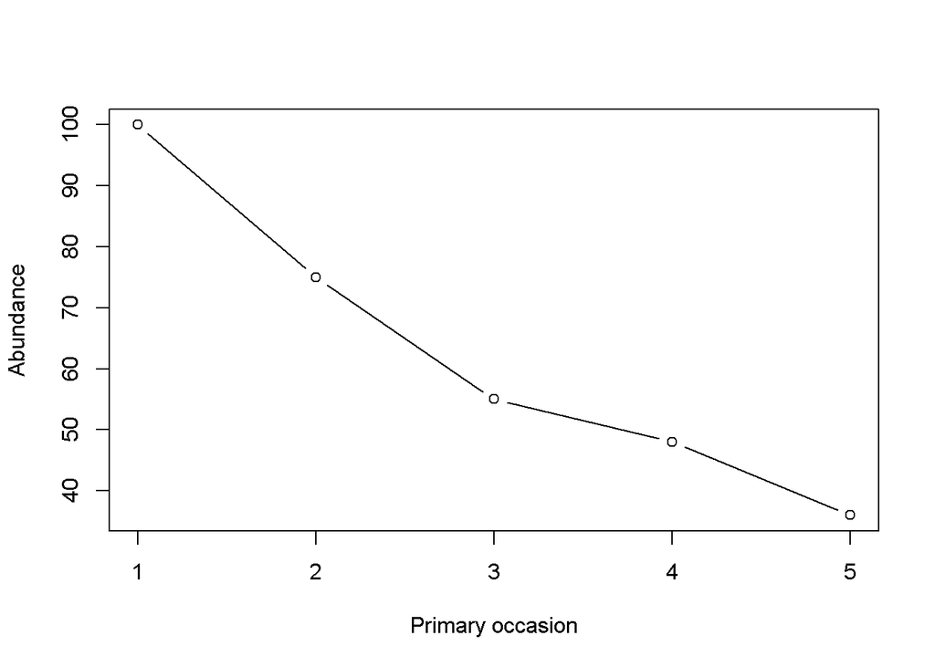

```r
plot(colSums(ZZ),ylab="Abundance",xlab="Primary occasion",type='b')
```

The next step is to model the observation process. This accounts for our imperfect ability to observe the process we modelled that is contained in the matrix ZZ. So there are come conditions to observation here as well. The biggie is that we cannot observe a fish that is not present in the super population (Z=0) or that is dead (ZZ=0). Given a fish is not there or alive the probability of capturing that fish is 0. If a fish is present in the super population and alive it has a probability of being capture equal to $p$. If we go out and try to capture fish 7 times (secondary occasions) and the probability of capture is independent among occasions (i.e., we are not more or less likely to capture a fish if it has been captured before) this capture process can be modelled as a series of 0s and 1s.

Lets go ahead and set an array to hold our data. Arrays are basically several matrices, the only hiccup is that they all have to be the same size. For this example it works because at every primary occasion we had 7 secondary occasions. In real life you will not likely have this and have to fill some columns with missing observations.

```r
ch<- array(NA,dim=c(200,nsec,nprim))
dim(ch)
```

```
## [1] 200   7   5
```

The code above generates 5 200x7 matrices. You get this from the dim statement where 200 represents the number of rows in each matrix, 7 is the number of columns and 5 is the number of matrices. The first matrix is for primary occasion 1, the second is for primary occasion 2, and so on. Now we can model the capture process conditional on inclusion in the super population and being alive.

```r
for(i in 1:nprim)
    for(j in 1:nsec)
        {
        ch[,j,i]<- rbinom(200,1,p*ZZ[,i]*Z)
        }
```

Lets look at the capture histories for the first and last 10 individuals on primary occasion 1.

```r
ch[1:10,,1]
```

```
##       [,1] [,2] [,3] [,4] [,5] [,6] [,7]
##  [1,]    0    0    0    1    0    0    1
##  [2,]    0    0    1    0    0    1    0
##  [3,]    0    1    0    0    0    1    0
##  [4,]    0    0    0    1    1    1    0
##  [5,]    0    0    0    1    1    1    1
##  [6,]    0    1    0    0    1    0    0
##  [7,]    0    1    1    1    1    1    0
##  [8,]    0    1    0    1    1    0    0
##  [9,]    1    0    1    0    1    1    1
## [10,]    1    1    0    0    0    1    0
```

```r
ch[190:200,,1]
```

```
##       [,1] [,2] [,3] [,4] [,5] [,6] [,7]
##  [1,]    0    0    0    0    0    0    0
##  [2,]    0    0    0    0    0    0    0
##  [3,]    0    0    0    0    0    0    0
##  [4,]    0    0    0    0    0    0    0
##  [5,]    0    0    0    0    0    0    0
##  [6,]    0    0    0    0    0    0    0
##  [7,]    0    0    0    0    0    0    0
##  [8,]    0    0    0    0    0    0    0
##  [9,]    0    0    0    0    0    0    0
## [10,]    0    0    0    0    0    0    0
## [11,]    0    0    0    0    0    0    0
```

You should notice that there are 1s and 0s for the first 10 individuals because they were in the super population and alive at the time of sampling. However the last 10 individuals were all 0s because they were not included in the super population. Instances of individuals that were included in the super population and alive but the capture history was all 0s indicated individuals that were present but not captured.

Looking at first 10 for the last primary occasion we see a few capture histories that are all 0s. These can either individuals that were present and not captured or individuals that died.

```r
ch[1:10,,5]
```

```
##       [,1] [,2] [,3] [,4] [,5] [,6] [,7]
##  [1,]    0    0    0    0    0    0    0
##  [2,]    0    0    0    0    0    0    0
##  [3,]    1    0    1    0    0    0    0
##  [4,]    0    0    0    0    0    0    0
##  [5,]    0    0    0    0    0    0    0
##  [6,]    0    0    0    0    0    0    0
##  [7,]    0    0    0    0    0    0    0
##  [8,]    0    0    0    0    0    0    0
##  [9,]    0    0    0    1    0    0    0
## [10,]    0    0    0    0    0    0    0
```

Below is a Bayesian state space model that should look very similar to the process that was just simulated. One of the major differences is having to do for loops for each individual. This is because neither JAGS or BUGS can allocate stochastic values as a vector. Stochastic values are defined with the $\sim$ in the code below.

The first code blocks define the process model. The second code block defines the observation model. The third code block defines derived values like population size and priors for estimated parameters.

```r
mod<- function()
    {
    # [1] PROCESS MODEL
    ## SUPER POPULATION
    for(j in 1:nind)
        {
        Z[j]~dbern(omega) # SUPER POPULATION SIZE, LATENT VARIABLE, DATA AUGMENTATION
        ZZ[j,1]<-Z[j]
        }

    ## ABUNDANCE AT EACH OCCASION
    for(i in 2:nprim)
        {
        for(j in 1:nind)
            {
            phi[j,i-1]<- (exp(b)/(1+exp(b)))*Z[j]*ZZ[j,i-1]
            ZZ[j,i]~dbern(phi[j,i-1])
            }
        }

    # [2] OBSERVATION MODEL
    for(i in 1:nprim)
        {
        for(j in 1:nind)
            {
            for(k in 1:nsec)
                {
                # ASSIGN CAPTURE PROBABILITY TO INDIVIDUALS
                p[j,k,i]<- (exp(a)/(1+exp(a)))*Z[j]*ZZ[j,i]
                ch[j,k,i]~dbern(p[j,k,i])
                }#k
            }#i
        }#j


    # [3] DERIVED PARAMETERS AND PRIORS
    ## DERIVED PARAMETERS
    N<-sum(Z[]) # SUPPER POPULATION
    for(i in 1:nprim){N_t[i]<- sum(ZZ[,i])}
    logit(phi_hat)<- b
    logit(p_hat)<-a
    ## PRIORS
    omega~dunif(0,1)
    a~dnorm(0,0.37)
    b~dnorm(0,0.37)
    }
```

To fit this type of model we need to give it some help with the unobserved state variables. In this model Z and ZZ are unobserved (AKA latent) variables. We do have some information in our capture histories that can give a good starting point for Z and ZZ. Specifically, if we captured a fish we know it was alive and has been alive since the start of the sampling.

```r
# INITIAL VALUES FOR ZZ
ZZ<- as.matrix(apply(ch,c(1,3),sum))# COUNT UP HOW MANY TIMES A FISH WAS CAPTURED
ZZ[ZZ>0]<-1 # ASSIGN FISH CAPTURED MORE THEN 0 TIMES AS ALIVE
indx<- which(rowSums(ZZ)>0)# FIGURE OUT WHICH FISH WERE ALIVE
last<-sapply(indx,function(x) max(which(ZZ[x,]==1)))# FIGURE OUT THE LAST TIME THEY WERE CAPTURED
# MAKE THE FISH BE ALIVE FROM THE FIRST OCCASION UP TO THE LAST CAPTURE
for(i in 1:length(indx))
    {
    ZZ[indx[i],c(1:last[i])]<-1
    }
```

The information contained in ZZ can be aggregated to inform Z. Specifically, Z should be 1 if a fish was captured at any point.

```r
Z<-rowSums(ZZ)# HOW MANY OCC WAS A FISH CAPTURED ON
Z[Z>0]<-1 # IF CAUGHT MORE THAN ONCE INCLUDE IT IN THE SUPER POPULATION
```

These initial values for the latent variables make initializing the model much easier and convergence go better.

```r
# DEFINE INTIAL VALUES OF ESTIMATED PARAMERTERS AND LATENT VARIABLES
inits<- function(t)
    {
    list(a=-2.5,b=0,omega=0.5,Z=Z,ZZ=ZZ)
    }
```

Once the initialization function is set we can bundle up our data for the model. Then define the parameters to keep track of.

```r
dat<- list(nprim=nprim, nind=nrow(ch[,,1]), nsec=nsec,ch=ch)
params<-c("N_t","omega","phi_hat","p_hat")
```

And finally we can run the model and see how it does!

```r
out <- jags(data=dat,
    inits=inits,
    parameters=params,
    model.file=mod,
    n.chains = 3,
    n.iter = 15000,
    n.burnin = 6000,
    n.thin=2,
    working.directory=getwd())
```

```
## module glm loaded
```

[output not shown]

```r
out
```

```
## Inference for Bugs model at "C:/Users/mcolvin/AppData/Local/Temp/RtmpCwJfOX/model1ab45a856239.txt", fit using jags,
##  3 chains, each with 15000 iterations (first 6000 discarded), n.thin = 2
##  n.sims = 13500 iterations saved
##           mu.vect sd.vect     2.5%      25%      50%      75%    97.5%
## N_t[1]    100.567   0.760  100.000  100.000  100.000  101.000  102.000
## N_t[2]     75.460   0.675   75.000   75.000   75.000   76.000   77.000
## N_t[3]     55.377   0.600   55.000   55.000   55.000   56.000   57.000
## N_t[4]     48.150   0.385   48.000   48.000   48.000   48.000   49.000
## N_t[5]     36.916   0.941   36.000   36.000   37.000   37.000   39.000
## omega       0.502   0.035    0.434    0.479    0.503    0.526    0.571
## p_hat       0.414   0.011    0.393    0.407    0.414    0.422    0.435
## phi_hat     0.770   0.025    0.719    0.753    0.771    0.788    0.818
## deviance 3006.755  12.051 2987.321 2996.176 3003.745 3013.507 3032.912
##           Rhat n.eff
## N_t[1]   1.001  3900
## N_t[2]   1.002  2800
## N_t[3]   1.001 14000
## N_t[4]   1.001 14000
## N_t[5]   1.001 13000
## omega    1.001  9000
## p_hat    1.001 14000
## phi_hat  1.001 13000
## deviance 1.001  5100
##
## For each parameter, n.eff is a crude measure of effective sample size,
## and Rhat is the potential scale reduction factor (at convergence, Rhat=1).
##
## DIC info (using the rule, pD = var(deviance)/2)
## pD = 72.6 and DIC = 3079.3
## DIC is an estimate of expected predictive error (lower deviance is better).
```

Lets compare the inputs and the estimates.

```r
# SUPER POPULATION INCLUSION
omega_true
```

```
## [1] 0.5
```

```r
out$BUGSoutput$mean$omega
```

```
## [1] 0.5023414
```

```r
# CONDITAIONAL CAPTURE PROBILITY
p
```

```
## [1] 0.4
```

```r
out$BUGSoutput$mean$p_hat
```

```
## [1] 0.4143848
```

```r
# SURVIVAL
phi
```

```
## [1] 0.8
```

```r
out$BUGSoutput$mean$phi_hat
```

```
## [1] 0.7701695
```